# Part II - (fordgobike-tripdata)

## by (Oluwadara Akano)

## Investigation Overview

> In this investigation, I will look at the types of users, how they share their trips and the preferred days and hours of riding and how that relates with the types of users. I will also check the age and gender distribution of the users.

## Dataset Overview

> Ford GoBike System dataset includes information about individual rides made in a bike-sharing system covering the greater San Francisco Bay area. The cleaned dataset has 174752 features and 29 columns which contains information about the duration, start time, end time of bike trips, the types of users, names of start and end stations with their ids, latitude and longitude, the id of the bikes used, birth year. age and genders of the members.

## Use Type Distribution

The distribution of the user types, most of the user types are subscribers

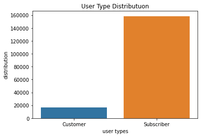

## Bike Share

The distribution of bike sharing, most of the users do not share their trip information

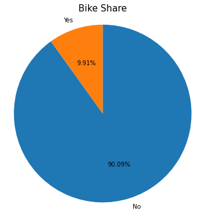

## Average User Duration

To check the average duration users(subscribers and customers) spend on their bike rides. It is shown that the customers spend more time in comparison to the subscribers

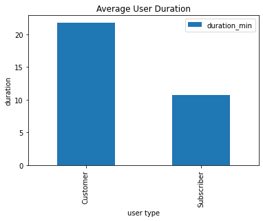

## Users Weekday Preference

To check the preferred days of riding for each user type. Most of the users ride more on thursdays. The number of subscribers ridng on saturdays and sundays are reduced while it is increased during the week. It might be because they have to ride to work during the week.

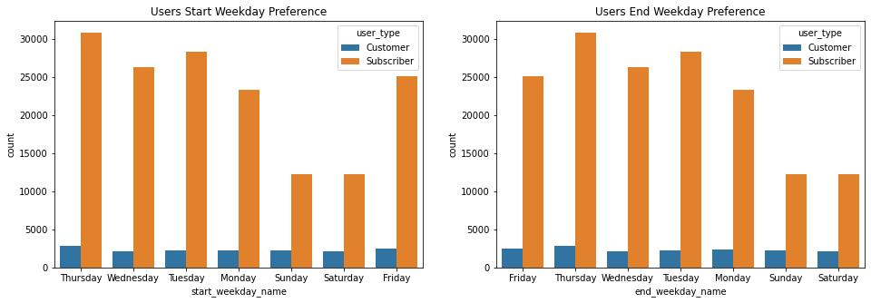

## Users Hour Preference

To check the preferred time of riding for users. It is shown that. Most subscribers prefer early morning (8am) and evening rides (5pm) which also relates with the beginning work hours and closing work hours.

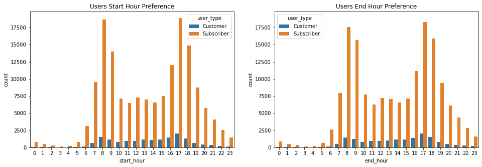

## Users Bike Sharing

To check the users that share their bike trips. The only people that shared their trips were all subscribers, although a larger percentage of them, didnt share. It might be that there is no share feature for customers, and that being a subscriber increases your chance of sharing your trip.

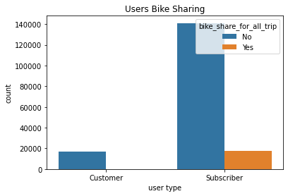

## User Type Duration

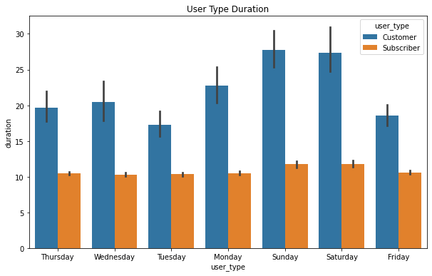

## Peak Riding Hours

Theres is an increse in the duration spent on riding between 2am and 3am for monday, wednesday, thursday, saturday and sunday, while Tuesday peaks at 12am. It seems people like spending more time on riding in the middle of the night compared to during the day

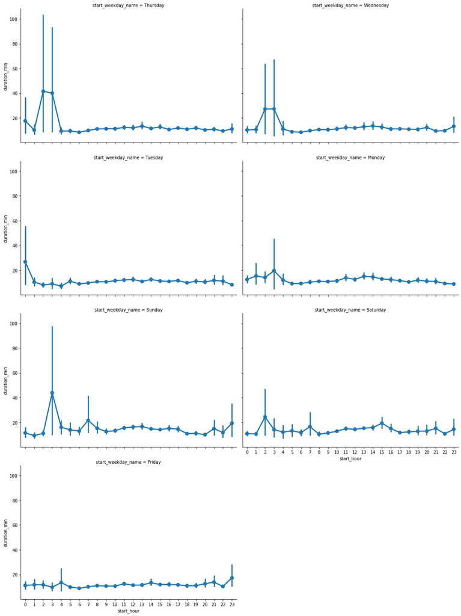

## Popular Stations

The preferred start stations constitute the end stations, which supports the insight that the users are routine riders that use the stations everyday to go to thier work places.

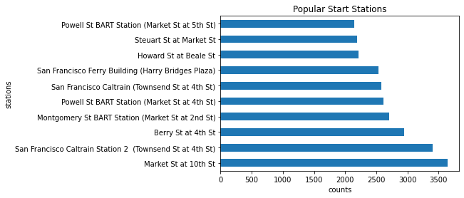

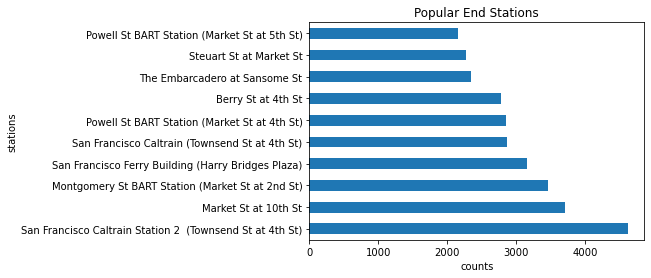

## Age Distribution

It is also noted that the average age range of riders are 30-40, because this is middle age where the energy to dispense for riding is available. About 29 people are above 100, I removed their representation in the plot. The older age group might be the leisure riders.

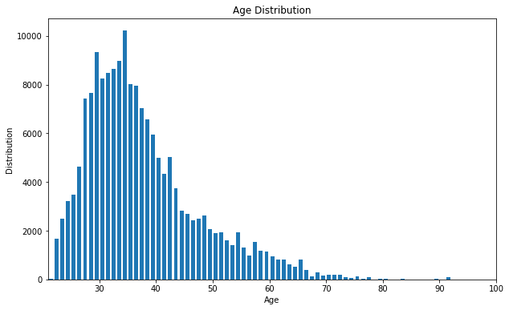

## Gender Duration

Males spend less time on their rides because they are more physically fit in comparison to females.

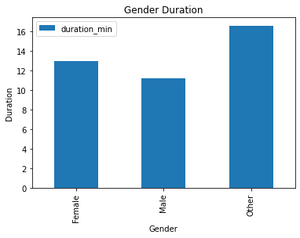